# Máster Universitario en Ciencia de Datos

### 4.4.6 Correlación

En este apartado buscaremos si existe correlación entre las variables numéricas que hemos usado con anterioridad, que son: puntuacion.general, precio, puntuacion.ergonomia_manejo, puntuacion.caracteristicas y  
puntuacion.visor.

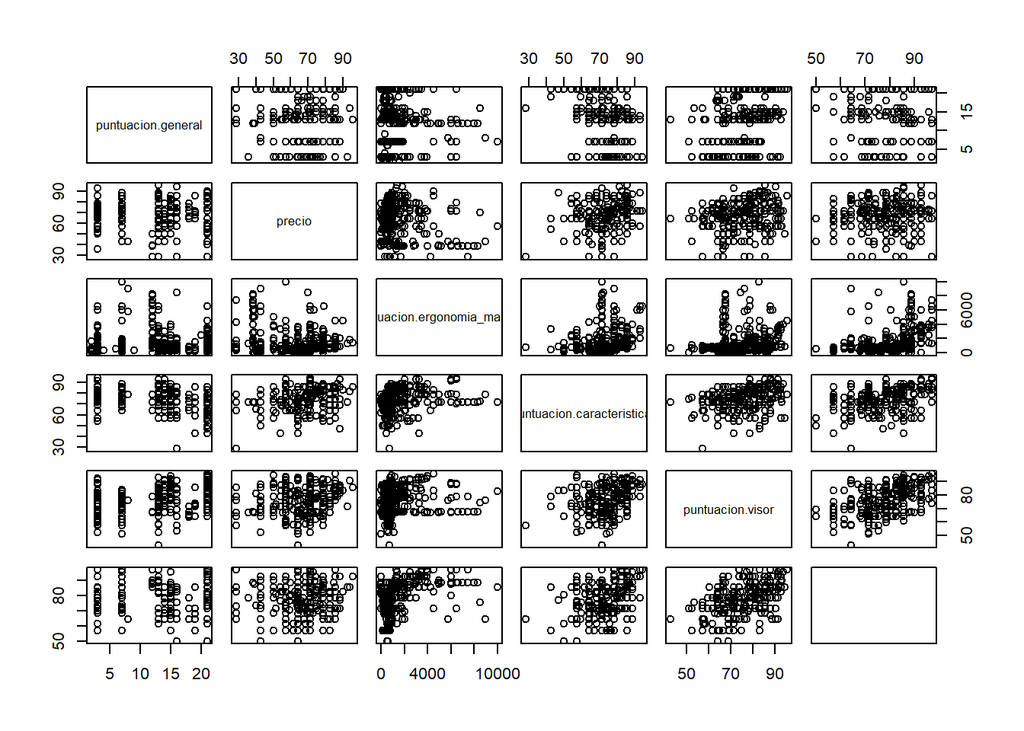

```r
data_correlation = select(data, x=c(puntuacion.general, precio, puntuacion.ergonomia_manejo, puntuacion.caracteristicas, puntuacion.visor))
colnames(data_correlation) = c("puntuacion.general", "precio", "puntuacion.ergonomia_manejo", "puntuacion.caracteristicas", "puntuacion.visor")
plot(data_correlation)
```

En los gráficos anteriores podemos ver las diferentes características numéricas pintadas una frente a otra. Aunque no se aprecia ningún caso de relación lineal, haremos el análisis de correlaciones en profundidad.

```r
cor.test(data$puntuacion.general, data$precio, method = "spearman")
```

```
##
##  Spearman's rank correlation rho
##
## data:  data$puntuacion.general and data$precio
## S = 13978072, p-value = 0.004397
## alternative hypothesis: true rho is not equal to 0
## sample estimates:
##       rho
## 0.1327136
```

```r
cor.test(data$puntuacion.general, data$puntuacion.ergonomia_manejo, method = "spearman")
```

```
##
##  Spearman's rank correlation rho
##
## data:  data$puntuacion.general and data$puntuacion.ergonomia_manejo
## S = 10993626, p-value = 3.088e-12
## alternative hypothesis: true rho is not equal to 0
## sample estimates:
##       rho
## 0.3178872
```

```r
cor.test(data$puntuacion.general, data$puntuacion.caracteristicas, method = "spearman")
```

```
##
##  Spearman's rank correlation rho
##
## data:  data$puntuacion.general and data$puntuacion.caracteristicas
## S = 12455838, p-value = 8.745e-07
## alternative hypothesis: true rho is not equal to 0
## sample estimates:
##       rho
## 0.2271624
```

```r
cor.test(data$puntuacion.general, data$puntuacion.visor, method = "spearman")
```

```
##
##  Spearman's rank correlation rho
##
## data:  data$puntuacion.general and data$puntuacion.visor
## S = 17611468, p-value = 0.0471
## alternative hypothesis: true rho is not equal to 0
## sample estimates:
##         rho
## -0.09272483
```

```r
cor.test(data$precio, data$puntuacion.ergonomia_manejo, method = "spearman")
```

```
##
##  Spearman's rank correlation rho
##
## data:  data$precio and data$puntuacion.ergonomia_manejo
## S = 10795394, p-value = 3.891e-13
## alternative hypothesis: true rho is not equal to 0
## sample estimates:
##       rho
## 0.3301867
```

```r
cor.test(data$precio, data$puntuacion.caracteristicas, method = "spearman")
```

```
##
##  Spearman's rank correlation rho
##
## data:  data$precio and data$puntuacion.caracteristicas
## S = 11073911, p-value = 6.96e-12
## alternative hypothesis: true rho is not equal to 0
## sample estimates:
##       rho
## 0.3129058
```

```r
cor.test(data$precio, data$puntuacion.visor, method = "spearman")
```

```
##
##  Spearman's rank correlation rho
##
## data:  data$precio and data$puntuacion.visor
## S = 10294338, p-value = 1.345e-15
## alternative hypothesis: true rho is not equal to 0
## sample estimates:
##       rho
## 0.3612753
```

```r
cor.test(data$puntuacion.ergonomia_manejo, data$puntuacion.caracteristicas, method = "spearman")
```

```
##
##  Spearman's rank correlation rho
##
## data:  data$puntuacion.ergonomia_manejo and data$puntuacion.caracteristicas
## S = 11404854, p-value = 1.693e-10
## alternative hypothesis: true rho is not equal to 0
## sample estimates:
##       rho
## 0.2923721
```

```r
cor.test(data$puntuacion.ergonomia_manejo, data$puntuacion.visor, method = "spearman")
```

```
##
##  Spearman's rank correlation rho
##
## data:  data$puntuacion.ergonomia_manejo and data$puntuacion.visor
## S = 12261179, p-value = 2.136e-07
## alternative hypothesis: true rho is not equal to 0
## sample estimates:
##       rho
## 0.2392403
```

```r
cor.test(data$puntuacion.caracteristicas, data$puntuacion.visor, method = "spearman")
```

```
##
##  Spearman's rank correlation rho
##
## data:  data$puntuacion.caracteristicas and data$puntuacion.visor
## S = 10953457, p-value = 2.045e-12
## alternative hypothesis: true rho is not equal to 0
## sample estimates:
##       rho
## 0.3203795
```

El test de correlación devuelve un resultado entre [-1,1] donde los extremos indican una alta correlación y el 0 una correlación nula.

Aún y así podemos encontrar una correlación positiva entre la puntuación de las características y la puntuación del visor, entre el precio y la punutuación de ergonomía y manejo, y entre el precio y la puntuación de las características.

# 5 Representación de los resultados a partir de tablas y gráficas.

Todos los resultados obtenidos se han ido presentando en cada uno de los apartados en tablas y gráficas.

# 6 Resolución del problema. A partir de los resultados obtenidos, ¿Cuáles son las conclusiones? ¿Los resultados permiten responder al problema?

Creemos que el dataset con el que se ha trabajado en esta práctica resulta ideal para los objetivos de la misma. Es un *dataset* que requiere mucho tratamiento de limpieza, extracción de valores y conversión de tipos. El hecho de que no sea un *dataset* académico clásico imposibilita encontrar referencias de trabajos previos de limpieza.

Los datos, una vez tratados, nos han servido para elaborar modelos, que aunque con baja precisión, se podrían emplear para realizar predicciones.

# 7 Referencias

- Introducción a la limpieza y análisis de datos. Calvo, M., Pérez, D., Subirats, L. (2019). Editorial UOC.
- Identificar y eliminar duplicados: [https://www.datanovia.com/en/lessons/identify-and-remove-duplicate-data-in-r/]
- Tabla con medidas de tendencia central y dispersión: [https://cran.r-project.org/web/packages/qwraps2/vignettes/summary-statistics.html]
- My favourite R package for: summarising data [https://dabblingwithdata.wordpress.com/2018/01/02/my-favourite-r-package-for-summarising-data/]